# C3하지혜_0527과제

## 서포트 벡터 머신

```python
# 데이터 처리
import pandas as pd
# 데이터 시각화
import matplotlib
import matplotlib.pyplot as plt
import seaborn as sns

# 데이터 스케일링
from sklearn.preprocessing import StandardScaler
# 데이터 분할: train, test
from sklearn.model_selection import train_test_split
# 분류 SVM
from sklearn.svm import SVC
# 최적모델 파라미터 탐색
from sklearn.model_selection import GridSearchCV

# 분류모델 평가 함수
from sklearn.metrics import accuracy_score, f1_score, precision_score, recall_score
from sklearn.metrics import confusion_matrix, classification_report
```

```python
matplotlib.rc('font', family='NanumGothic')
matplotlib.rcParams['axes.unicode_minus'] = False
plt.rcParams["font.family"] = 'NanumGothic'
```

### 데이터 구성하기

```python
df_raw = pd.read_csv('../빅데이터 기초/Data/유방암.csv',encoding='euc-kr')
df_raw.head()
```

|  | diagnosis | mean_radius | mean_texture | mean_perimeter | mean_area | mean_smoothness | mean_compactness | mean_concavity | mean_concave_points | mean_symmetry | ... | worst_radius | worst_texture | worst_perimeter | worst_area | worst_smoothness | worst_compactness | worst_concavity | worst_concave_points | worst_symmetry | worst_fractal_dimension |
| --- | --- | --- | --- | --- | --- | --- | --- | --- | --- | --- | --- | --- | --- | --- | --- | --- | --- | --- | --- | --- | --- |
| 0 | 음성 | 15.12 | 16.68 | 98.78 | 716.6 | 0.08876 | 0.09588 | 0.07550 | 0.04079 | 0.1594 | ... | 17.77 | 20.24 | 117.70 | 989.5 | 0.14910 | 0.3331 | 0.3327 | 0.12520 | 0.3415 | 0.09740 |
| 1 | 양성 | 10.80 | 9.71 | 68.77 | 357.6 | 0.09594 | 0.05736 | 0.02531 | 0.01698 | 0.1381 | ... | 11.60 | 12.02 | 73.66 | 414.0 | 0.14360 | 0.1257 | 0.1047 | 0.04603 | 0.2090 | 0.07699 |
| 2 | 음성 | 18.31 | 18.58 | 118.60 | 1041.0 | 0.08588 | 0.08468 | 0.08169 | 0.05814 | 0.1621 | ... | 21.31 | 26.36 | 139.20 | 1410.0 | 0.12340 | 0.2445 | 0.3538 | 0.15710 | 0.3206 | 0.06938 |
| 3 | 양성 | 14.92 | 14.93 | 96.45 | 686.9 | 0.08098 | 0.08549 | 0.05539 | 0.03221 | 0.1687 | ... | 17.18 | 18.22 | 112.00 | 906.6 | 0.10650 | 0.2791 | 0.3151 | 0.11470 | 0.2688 | 0.08273 |
| 4 | 양성 | 12.89 | 13.12 | 81.89 | 515.9 | 0.06955 | 0.03729 | 0.02260 | 0.01171 | 0.1337 | ... | 13.62 | 15.54 | 87.40 | 577.0 | 0.09616 | 0.1147 | 0.1186 | 0.05366 | 0.2309 | 0.06915 |

5 rows × 31 columns

```python
# 데이터 분리 (Y, Xs) -> 설명변수를 이용한 주성분 분석
df_raw_x = df_raw.drop("diagnosis", axis = 1)
df_raw_y = df_raw["diagnosis"]
df_raw_y.head()
```

```
0    음성
1    양성
2    음성
3    양성
4    양성
Name: diagnosis, dtype: object
```

```python
df_raw_y.replace("양성", 1, inplace=True)
df_raw_y.replace("음성", 0, inplace=True)
```

양성을 1, 음성을 0으로 변환하였다.

```python
df_raw_y.head()
```

```
0    0
1    1
2    0
3    1
4    1
Name: diagnosis, dtype: int64
```

```python
df_raw['diagnosis'].value_counts() # oversampling 안해도 될 것 같다.
```

```
0    212
1    108
Name: diagnosis, dtype: int64
```

```python
# get dummies : 데이터의 문자형 변수에 대한 더미변수 생성
df_raw_dummy = pd.get_dummies(df_raw)
# 더미변수 생성된 데이터의 상위 5개 row 확인
df_raw_dummy.head()
```

|  | diagnosis | mean_radius | mean_texture | mean_perimeter | mean_area | mean_smoothness | mean_compactness | mean_concavity | mean_concave_points | mean_symmetry | ... | worst_radius | worst_texture | worst_perimeter | worst_area | worst_smoothness | worst_compactness | worst_concavity | worst_concave_points | worst_symmetry | worst_fractal_dimension |
| --- | --- | --- | --- | --- | --- | --- | --- | --- | --- | --- | --- | --- | --- | --- | --- | --- | --- | --- | --- | --- | --- |
| 0 | 0 | 15.12 | 16.68 | 98.78 | 716.6 | 0.08876 | 0.09588 | 0.07550 | 0.04079 | 0.1594 | ... | 17.77 | 20.24 | 117.70 | 989.5 | 0.14910 | 0.3331 | 0.3327 | 0.12520 | 0.3415 | 0.09740 |
| 1 | 1 | 10.80 | 9.71 | 68.77 | 357.6 | 0.09594 | 0.05736 | 0.02531 | 0.01698 | 0.1381 | ... | 11.60 | 12.02 | 73.66 | 414.0 | 0.14360 | 0.1257 | 0.1047 | 0.04603 | 0.2090 | 0.07699 |
| 2 | 0 | 18.31 | 18.58 | 118.60 | 1041.0 | 0.08588 | 0.08468 | 0.08169 | 0.05814 | 0.1621 | ... | 21.31 | 26.36 | 139.20 | 1410.0 | 0.12340 | 0.2445 | 0.3538 | 0.15710 | 0.3206 | 0.06938 |
| 3 | 1 | 14.92 | 14.93 | 96.45 | 686.9 | 0.08098 | 0.08549 | 0.05539 | 0.03221 | 0.1687 | ... | 17.18 | 18.22 | 112.00 | 906.6 | 0.10650 | 0.2791 | 0.3151 | 0.11470 | 0.2688 | 0.08273 |
| 4 | 1 | 12.89 | 13.12 | 81.89 | 515.9 | 0.06955 | 0.03729 | 0.02260 | 0.01171 | 0.1337 | ... | 13.62 | 15.54 | 87.40 | 577.0 | 0.09616 | 0.1147 | 0.1186 | 0.05366 | 0.2309 | 0.06915 |

5 rows × 31 columns

```python
# 설명변수, 목표변수 데이터 구분
df_raw_x = df_raw_dummy.drop("diagnosis", axis = 1, inplace= False)
df_raw_y = df_raw_dummy["diagnosis"]

# 데이터 분할 train_test_split(X:설명변수, Y: 목표변수 , test_size = test 데이터 비율)
df_train_x, df_test_x, df_train_y, df_test_y = train_test_split(df_raw_x, df_raw_y, test_size= 0.4, random_state=1234)
print("분할 전 설명변수 데이터: ", df_raw_x.shape)
print("분할 후 설명변수 데이터: Train", df_raw_x.shape, "Test", df_test_x.shape)
```

```
분할 전 설명변수 데이터:  (320, 30)
분할 후 설명변수 데이터: Train (320, 30) Test (128, 30)
```

### SVC 모델 생성

```python
# 기본 옵션으로 모델 생성
svm_uncustomized = SVC(random_state=1234)
svm_uncustomized.fit(df_train_x, df_train_y)

print("Accuracy on training set: {:.3f}".format(svm_uncustomized.score(df_train_x, df_train_y)))
print("Accuracy on test set: {:.3f}".format(svm_uncustomized.score(df_test_x, df_test_y)))
```

```
Accuracy on training set: 0.885
Accuracy on test set: 0.891
```

- 기본 옵션으로 생성했을 때 train data의 정확도는 0.885, test data의 정확도는 0.891이다. training data에 과적합되지는 않았다고 볼 수 있다.

### SVC 모델 Parameter 변경

#### C: 규제에 대한 강도 변경

```python
# train 및 test 정확도 결과 저장용
train_accuracy = []
test_accuracy = []

# c: 규제(0.01,0.1,1,10)
para_c = [10**c for c in range(-2,2)]

# para_c = [0.1*c for c in range(1,10)] #c 변화 구간 변경
for v_C in para_c:
    svm = SVC(C=v_C,random_state=1234)
    svm.fit(df_train_x,df_train_y)
    train_accuracy.append(svm.score(df_train_x, df_train_y))
    test_accuracy.append(svm.score(df_test_x, df_test_y))

# 데이터 테이블로 저장
df_accuracy_c = pd.DataFrame()
df_accuracy_c['C'] = para_c
df_accuracy_c['TrainAccuracy'] = train_accuracy
df_accuracy_c['TestAccuracy'] = test_accuracy
```

```python
# C 별 정확도 테이블
df_accuracy_c.round(3)
```

|  | C | TrainAccuracy | TestAccuracy |
| --- | --- | --- | --- |
| 0 | 0.01 | 0.599 | 0.758 |
| 1 | 0.10 | 0.854 | 0.859 |
| 2 | 1.00 | 0.885 | 0.891 |
| 3 | 10.00 | 0.906 | 0.922 |

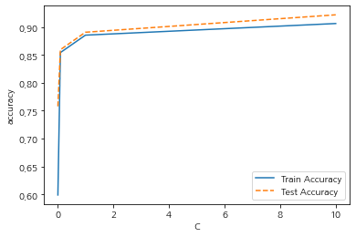

```python
# 모델 정확도 그래프 확인
plt.plot(para_c,train_accuracy,linestyle='-',label = 'Train Accuracy')
plt.plot(para_c,test_accuracy,linestyle='--',label = 'Test Accuracy')
plt.ylabel('accuracy');plt.xlabel('C')
plt.legend()
```

- C가 커질수록 train/test 정확도가 높아진다.

#### Gamma: 훈련 샘플이 미치는 영향의 범위를 변경

```python
# train 및 test 정확도 결과 저장용
train_accuracy = []
test_accuracy = []

# gamma: 규제(0.01,0.1,1,10)
para_gamma = [10 ** gamma for gamma in range(-2,2)]
for i in para_gamma:
    svm = SVC(gamma = i, C=0.1, random_state=1234)
    svm.fit(df_train_x, df_train_y)
    train_accuracy.append(svm.score(df_train_x, df_train_y))
    test_accuracy.append(svm.score(df_test_x, df_test_y))

# 데이터 테이블로 저장
df_accuracy_gamma = pd.DataFrame()
df_accuracy_gamma['gamma'] = para_gamma
df_accuracy_gamma['TrainAccuracy'] = train_accuracy
df_accuracy_gamma['TestAccuracy'] = test_accuracy
```

```python
df_accuracy_gamma.round(4)
```

|  | gamma | TrainAccuracy | TestAccuracy |
| --- | --- | --- | --- |
| 0 | 0.01 | 0.599 | 0.7578 |
| 1 | 0.10 | 0.599 | 0.7578 |
| 2 | 1.00 | 0.599 | 0.7578 |
| 3 | 10.00 | 0.599 | 0.7578 |

```
<function matplotlib.pyplot.legend(*args, **kwargs)>
```

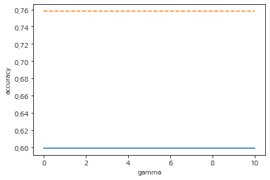

```python
plt.plot(para_gamma, train_accuracy, linestyle ='-', label = 'Train Accuracy')
plt.plot(para_gamma, test_accuracy, linestyle = '--', label = 'Test Accuracy')
plt.ylabel('accuracy')
plt.xlabel('gamma')
plt.legend
```

- gamma 변화는 정확도에 영향을 미치지 않는다.

#### Standatdscaler: 설명변수 값의 구간을 동일하게 변경

```python
# 변수명 저장
v_feature_name = df_train_x.columns

# StandardScaler 적용
scaler = StandardScaler()
df_scaled = scaler.fit_transform(df_raw_x)
df_scaled = pd.DataFrame(df_scaled, columns=v_feature_name)
df_scaled.head()
```

|  | mean_radius | mean_texture | mean_perimeter | mean_area | mean_smoothness | mean_compactness | mean_concavity | mean_concave_points | mean_symmetry | mean_fractal_dimension | ... | worst_radius | worst_texture | worst_perimeter | worst_area | worst_smoothness | worst_compactness | worst_concavity | worst_concave_points | worst_symmetry | worst_fractal_dimension |
| --- | --- | --- | --- | --- | --- | --- | --- | --- | --- | --- | --- | --- | --- | --- | --- | --- | --- | --- | --- | --- | --- |
| 0 | -0.157678 | -0.879112 | -0.165550 | -0.232872 | -0.744948 | -0.479220 | -0.550769 | -0.628488 | -0.997431 | -0.392627 | ... | -0.149283 | -1.156442 | -0.153789 | -0.224951 | 0.490637 | 0.139396 | -0.094470 | -0.301949 | 0.525611 | 0.511081 |
| 1 | -1.312779 | -2.560965 | -1.328928 | -1.150194 | -0.240274 | -1.153621 | -1.143404 | -1.199934 | -1.773612 | 0.184077 | ... | -1.341759 | -2.517236 | -1.380396 | -1.124201 | 0.254373 | -1.046076 | -1.159323 | -1.480312 | -1.387506 | -0.507149 |
| 2 | 0.695279 | -0.420644 | 0.602798 | 0.596040 | -0.947380 | -0.675307 | -0.477679 | -0.212084 | -0.899042 | -1.174101 | ... | 0.534893 | -0.143296 | 0.445031 | 0.432104 | -0.613360 | -0.367031 | 0.004076 | 0.172850 | 0.223844 | -0.886803 |
| 3 | -0.211154 | -1.301385 | -0.255876 | -0.308762 | -1.291796 | -0.661126 | -0.788224 | -0.834410 | -0.658535 | -0.834209 | ... | -0.263312 | -1.490846 | -0.312546 | -0.354487 | -1.339335 | -0.169261 | -0.176669 | -0.458230 | -0.524077 | -0.220788 |
| 4 | -0.753945 | -1.738136 | -0.820314 | -0.745704 | -2.095198 | -1.505004 | -1.175403 | -1.326415 | -1.933950 | -0.956793 | ... | -0.951354 | -1.934512 | -0.997708 | -0.869505 | -1.783511 | -1.108951 | -1.094404 | -1.366747 | -1.071301 | -0.898278 |

5 rows × 30 columns

```python
# 데이터 분할
df_scaled_train_x, df_scaled_test_x = train_test_split(df_scaled, test_size=0.4, random_state=1234)
print("train data X size : {}".format(df_scaled_train_x.shape))
print("test data X size : {}".format(df_scaled_test_x.shape))
```

```
train data X size : (192, 30)
test data X size : (128, 30)
```

#### scale 조절 후 SVC 모델 재실행

```python
# Scale이 조정된 데이터로 새로운 모델 생성
svm_scaled = SVC(random_state=1234)
svm_scaled.fit(df_scaled_train_x, df_train_y)
# train 데이터 셋 정확도
print("Accuracy on training set: {:.3f}".format(svm_scaled.score(df_scaled_train_x, df_train_y)))
# test 셋 정확도
print("Accuracy on test set: {:.3f}".format(svm_scaled.score(df_scaled_test_x, df_test_y)))
```

```
Accuracy on training set: 0.995
Accuracy on test set: 0.961
```

- scale 조정 후, 기존의 정확도보다 상승한 것을 확인할 수 있다.
- train data 상승량: 0.110
- test data 상승량: 0.070

### 새로운 SVC 모델

#### C: 규제에 대한 강도 변경

```python
train_accuracy = []
test_accuracy = []

#c: 규제(0.01, 0.1, 1, 10)
para_c = [10**c for c in range(-2,2)]
for v_C in para_c:
    svm = SVC(C = v_C, random_state = 1234)
    svm.fit(df_scaled_train_x, df_train_y)
    train_accuracy.append(svm.score(df_scaled_train_x, df_train_y))
    test_accuracy.append(svm.score(df_scaled_test_x, df_test_y))

    #데이터 테이블로 저장
df_accuracy_c = pd.DataFrame()
df_accuracy_c["C"] = para_c
df_accuracy_c["TrainAccuracy"] = train_accuracy
df_accuracy_c["TestAccuracy"] = test_accuracy
```

```python
df_accuracy_c.round(3)
```

|  | C | TrainAccuracy | TestAccuracy |
| --- | --- | --- | --- |
| 0 | 0.01 | 0.599 | 0.758 |
| 1 | 0.10 | 0.964 | 0.906 |
| 2 | 1.00 | 0.995 | 0.961 |
| 3 | 10.00 | 1.000 | 0.961 |

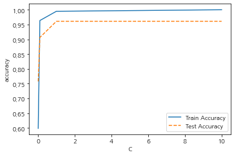

```python
df_accuracy_c.round(3)

#모델 정확도 그래프 확인
plt.plot(para_c, train_accuracy, linestyle = '-', label="Train Accuracy")
plt.plot(para_c, test_accuracy, linestyle = '--', label="Test Accuracy")
plt.ylabel("accuracy")
plt.xlabel("C")
plt.legend()
```

- C가 증가할수록 모델의 정확도가 증가한다. train data 과적합을 방지하기 위해 10은 선택하지 않는 것이 좋아보인다.

#### Gamma: 훈련 샘플이 미치는 영향의 범위를 변경 결과

```python
# train 및 test 정확도 결과 저장용
train_accuracy = []
test_accuracy = []

# gamma: 규제(0.01, 0.1, 1, 10)
para_gamma = [10 **gamma for gamma in range(-2, 2)]

for v_gamma in para_gamma:
    svm = SVC(gamma = v_gamma, C = 1, random_state=1234)
    svm.fit(df_scaled_train_x, df_train_y)
    train_accuracy.append(svm.score(df_scaled_train_x, df_train_y))
    test_accuracy.append(svm.score(df_scaled_test_x, df_test_y))

# 데이터 테이블로 저장
df_accuracy_gamma = pd.DataFrame()
df_accuracy_gamma["gamma"] = para_gamma
df_accuracy_gamma["TrainAccuracy"] = train_accuracy
df_accuracy_gamma["TestAccuracy"] = test_accuracy
```

#### 새로운 SVC 모델 평가

```python
df_accuracy_gamma.round(3)
```

|  | gamma | TrainAccuracy | TestAccuracy |
| --- | --- | --- | --- |
| 0 | 0.01 | 0.995 | 0.938 |
| 1 | 0.10 | 1.000 | 0.922 |
| 2 | 1.00 | 1.000 | 0.773 |
| 3 | 10.00 | 1.000 | 0.766 |

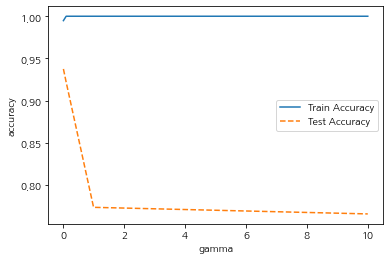

```python
plt.plot(para_gamma, train_accuracy, linestyle="-", label="Train Accuracy")
plt.plot(para_gamma, test_accuracy, linestyle="--", label="Test Accuracy")
plt.ylabel("accuracy")
plt.xlabel("gamma")
plt.legend()
```

- gamma가 1 이상이면 train data에 과적합된다. 그렇기 때문에 0.01을 선택하는 것이 좋아보인다.

### 결론

#### 최종 모델

```python
svc_final=SVC(gamma=0.01,C=1,random_state=1234)
svc_final.fit(df_scaled_train_x,df_train_y)
y_pred=svc_final.predict(df_scaled_test_x)

print("Accuracy on training set:{:.3f}".format(svc_final.score(df_scaled_train_x,df_train_y)))
print("Accuracy on test set:{:.3f}".format(svc_final.score(df_scaled_test_x,df_test_y)))
print("Confusion matrix: \n{}".format(confusion_matrix(df_test_y,y_pred)))
print(classification_report(df_test_y,y_pred,digits=3))
```

```
Accuracy on training set:0.995
Accuracy on test set:0.938
Confusion matrix:
[[91  6]
 [ 2 29]]
              precision    recall  f1-score   support

           0      0.978     0.938     0.958        97
           1      0.829     0.935     0.879        31

    accuracy                          0.938       128
   macro avg      0.904     0.937     0.918       128
weighted avg      0.942     0.938     0.939       128
```

- test data 기준 정분류율은 (91+29)/128 = 93.75%이다.
- '1' 기준 f1 score는 87.9%이다. precision이 recall보다 약 10% 정도 낮다. 하지만 이것은 데이터 개수가 적어서 차이가 크게 보이는 것이고, 데이터 수가 많아진다면 차이가 10% 보다 줄어들 것이라 생각된다.

### GridSearchCV

```python
estimator = SVC(random_state=1234)
param_grid={"C":para_c,"gamma":para_gamma}

#정확도가 높은 최적 parameter찾기
grid_rf=GridSearchCV(estimator,param_grid,scoring="accuracy",n_jobs=-1)
grid_rf.fit(df_scaled_train_x,df_train_y)

print("best estimator model: \n{}".format(grid_rf.best_estimator_))
print("\nbest parameter: \n{}".format(grid_rf.best_params_))
print("\nbest score:\n{}".format(grid_rf.best_score_.round(3)))
```

```
best estimator model:
SVC(C=10, gamma=0.01, random_state=1234)

best parameter:
{'C': 10, 'gamma': 0.01}

best score:
0.989
```

- GridSearchCV를 이용하여 파라미터를 찾아보니 C=10, gamma=0.01이 나왔고 정확도는 98.9%가 나왔다.

## Confusion Matrix

```python
# training set에 모델 적합
svm_final = SVC(gamma = 0.01, C= 10, random_state=1234)
svm_final.fit(df_scaled_train_x, df_train_y)
```

```
SVC(C=10, gamma=0.01, random_state=1234)
```

```python
# test set 예측
y_pred =svm_final.predict(df_scaled_test_x)

# 결과 평가
cm = confusion_matrix(df_test_y, y_pred)
cm
```

```
array([[92,  5],
       [ 0, 31]], dtype=int64)
```

```python
print(accuracy_score(df_test_y, y_pred))
print(precision_score(df_test_y, y_pred))
print(recall_score(df_test_y, y_pred))
print(f1_score(df_test_y, y_pred))
```

```
0.9609375
0.8611111111111112
1.0
0.9253731343283582
```

- 모델의 최종 정확도는 96%이다.
- 정밀도는 86%로, 정확도에 비해 낮은 편이다.
- 재현율은 100%로 나왔다.
- f1 score는 92.5%가 나왔다.

마지막으로 Confusion Matrix를 나타내면 다음과 같다.

```
Test Data Accuracy: 0.9609
```

[figure not shown]

```python
df_cm = pd.DataFrame(cm, index = (1, 0), columns = (1, 0))
plt.figure(figsize = (10,7))
sns.set(font_scale=1.4)
sns.heatmap(df_cm, annot=True, fmt='g')
print("Test Data Accuracy: %0.4f" % accuracy_score(df_test_y, y_pred))
```